# Data Report

Ken Butler

2022-12-18

This report contains some analysis of one or more datasets.

# Making soap

A company operates two production lines in a factory for making soap bars. The production lines are labelled A and B. A production line that moves faster may produce more soap, but may possibly also produce more “scrap” (that is, bits of soap that can no longer be made into soap bars and will have to be thrown away).

The data:

| case | scrap | speed | line |
| --- | --- | --- | --- |
| 1 | 218 | 100 | a |
| 2 | 248 | 125 | a |
| 3 | 360 | 220 | a |
| 4 | 351 | 205 | a |
| 5 | 470 | 300 | a |
| 6 | 394 | 255 | a |
| 7 | 332 | 225 | a |
| 8 | 321 | 175 | a |
| 9 | 410 | 270 | a |
| 10 | 260 | 170 | a |

[output cut: 17 more lines]

We can plot scrap against speed separately for each line, thus:

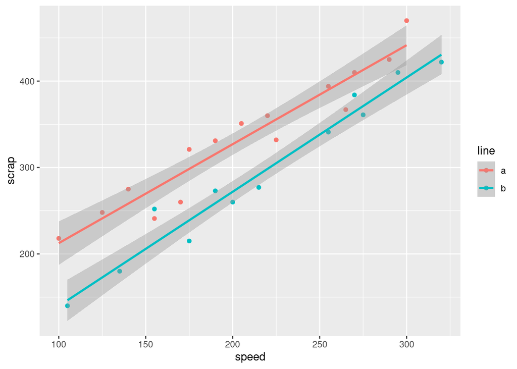

This suggests an ANCOVA model with a common slope:

```
##
## Call:
## lm(formula = scrap ~ speed + line, data = x)
##
## Residuals:
##     Min      1Q  Median      3Q     Max
## -39.557 -14.161  -0.121  17.518  33.953
##
## Coefficients:
##              Estimate Std. Error t value Pr(>|t|)
## (Intercept)  80.41099   14.54379   5.529 1.10e-05 ***
## speed         1.23074    0.06555  18.775 7.48e-16 ***
## lineb       -53.12920    8.21003  -6.471 1.08e-06 ***
## ---
## Signif. codes:  0 '***' 0.001 '**' 0.01 '*' 0.05 '.' 0.1 ' ' 1
##
## Residual standard error: 21.13 on 24 degrees of freedom
## Multiple R-squared:  0.9402, Adjusted R-squared:  0.9352
## F-statistic: 188.6 on 2 and 24 DF,  p-value: 2.104e-15
```

We see that scrap depends independently on speed and on production line. An increase in speed of one unit increases the amount of scrap by 1.23 units on average (for either production line), and line A produces about 53 units more scrap than line B, at the same speed.

# Spiders on the beach

A team of Japanese researchers were investigating what would cause the burrowing wolf spider *Lycosa ishikariana* to be found on a beach. They hypothesized that it had to do with the size of the grains of sand on the beach. They went to 28 beaches in Japan, measured the average sand grain size (in millimetres), and observed the presence or absence of this particular spider on each beach.

We read in and examine the data first. The layout of the data implies `read_table`:

```r
my_url <- "http://ritsokiguess.site/datafiles/spiders.txt"
spider <- read_table(my_url)
spider
```

| Grain.size | Spiders |
| --- | --- |
| 0.245 | absent |
| 0.247 | absent |
| 0.285 | present |
| 0.299 | present |
| 0.327 | present |
| 0.347 | present |
| 0.356 | absent |
| 0.360 | present |
| 0.363 | absent |
| 0.364 | present |

[output cut: 18 more lines]

The response variable is `Spiders`, which indicates whether or not this spider is present on the beach concerned. This is categorical, so to model how this depends on grain size, we need a logistic regression.

One way to make a graph is to note that we have one categorical and one quantitative variable, and thus to make a boxplot:

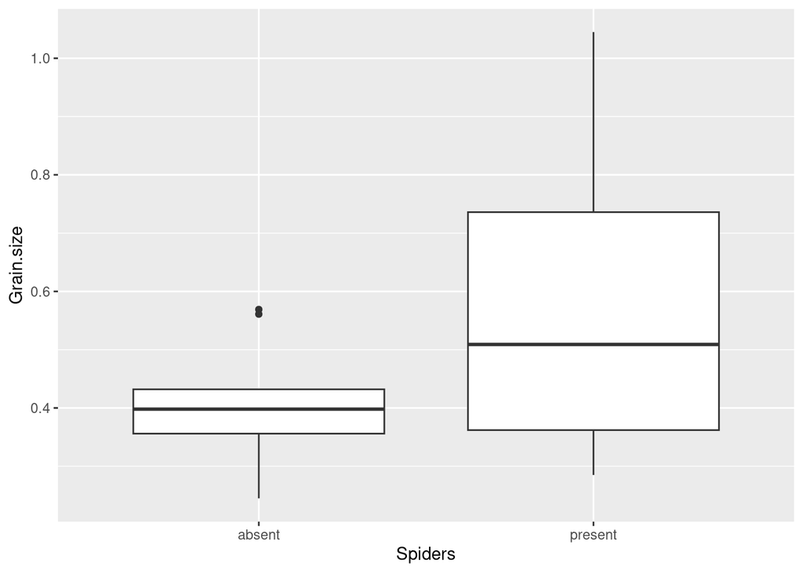

```r
ggplot(spider, aes(x = Spiders, y = Grain.size)) + geom_boxplot()
```

This says that when spiders are present, the grains of sand tend to be larger (and when they are absent, the grains tend to be smaller). Logically, though, this is the wrong way around, because it suggests that grain size is the response and presence/absence of spiders is explanatory, whereas in fact these should be reversed.

The value of the plot, though, is to illustrate that there seems to be a connection between grain size and presence/absence of spiders, which is what we wanted to know.

Now we fit the logistic regression:

```r
Spiders.1 <- glm(factor(Spiders) ~ Grain.size, family = "binomial", data = spider)
summary(Spiders.1)
```

```
##
## Call:
## glm(formula = factor(Spiders) ~ Grain.size, family = "binomial",
##     data = spider)
##
## Deviance Residuals:
##     Min       1Q   Median       3Q      Max
## -1.7406  -1.0781   0.4837   0.9809   1.2582
##
## Coefficients:
##             Estimate Std. Error z value Pr(>|z|)
## (Intercept)   -1.648      1.354  -1.217   0.2237
## Grain.size     5.122      3.006   1.704   0.0884 .
## ---
## Signif. codes:  0 '***' 0.001 '**' 0.01 '*' 0.05 '.' 0.1 ' ' 1
##
## (Dispersion parameter for binomial family taken to be 1)
##
##     Null deviance: 35.165  on 27  degrees of freedom
## Residual deviance: 30.632  on 26  degrees of freedom
## AIC: 34.632
##
## Number of Fisher Scoring iterations: 5
```

It turns out that the effect of grain size is not quite significant (at $\alpha = 0.05$). This is for a couple of reasons:

- the sample size ($n = 28$) is not very large for a logistic regression, because each beach only contains information about whether the spider is present or not (not, for example, how many spiders were seen)
- the boxplot shows that there is substantial overlap in grain sizes between beaches where the spider was present and where it was absent. Some of the beaches with the spider have small grain sizes, and there are two outlier (high) grain sizes on beaches without the spider.

Though there is a tendency for the spider to be present on beaches where the grains are larger and absent where the grains are smaller, this tendency is not clear-cut enough to be generalizable to other beaches.